# Unsupervised Learning Project

### C. Print Classification metrics for train data of above model and share relative improvement in performance in all the models along with insights. [2 Marks]

```
Training Set
              precision    recall  f1-score   support

           0       0.94      0.90      0.92       140
           1       0.95      0.92      0.93       311
           2       0.86      0.97      0.91       141

    accuracy                           0.93       592
   macro avg       0.92      0.93      0.92       592
weighted avg       0.93      0.93      0.93       592
```

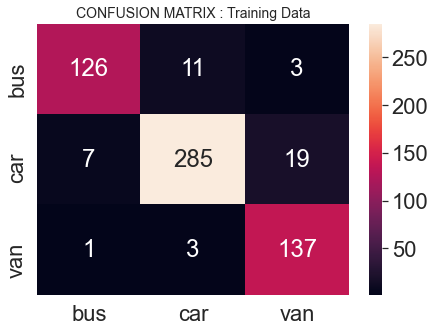

```
Test Set
              precision    recall  f1-score   support

           0       0.94      0.81      0.87        78
           1       0.88      0.93      0.91       118
           2       0.87      0.93      0.90        58

    accuracy                           0.89       254
   macro avg       0.90      0.89      0.89       254
weighted avg       0.90      0.89      0.89       254
```

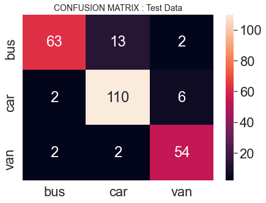

```python
ClassificationReport(CV_rf,X_train_pca, X_test_pca, y_train_pca, y_test_pca)
```

Observation:

Training Data:

[output not shown]

Test Data:

```
Total number of Type-I and Type-II errors are 27

From the classification report, it can be seen that the model has an average weighted performance of around 89%
ranging from precision, recall, f1-score, and support.


- IN case of 58 actual vans our svm model has correcly classified 54 vans. it has wrongly classified 2 vans to be a cars and 2 vans to be a bus

- IN case of 118 actual cars our svm model has correcly classified 110 cars. it has wrongly classified 2 cars to be a bus and also 6 cars to be a van

- In case of 78 actual bus  our svm model has correctly classified 63 buses , It has wrongly classified 2 bus to be a van and 13 buses to be a car.
```

On training data , support vector classifier with performing PCA has an accuracy score of 81 %

But when we applied hypertuning the SVC model on PCA componenets(reduced dimensions) our model scored increased to 93%.

After Hypertuning SVM the model accuracy is increased from 81% to 93% for training set and 82% to 89% for test set.

5. Data Understanding & Cleaning: [5 Marks]

### B. Explain advantages and limitations of PCA. [3 Marks]

Advantages of PCA

- Removes the correlated attributes.
- Help to reduce overfitting.
- Improves the data visualization.
- PCA helps in selecting relevant features by analysing the relationship between independent attributes to see which one will be more helpful in building our model without introducing any impurity in it
- We can increase the models performance both in terms of processing speed and the ease of implementing it .

Disadvantages of PCA

- Data normalization must be needed before applying PCA else the result will not be as per expectations
- Some level of information loss.
- Independent variables are become less interpretable.